# BIOS611 Project 1

Yen Chang

October 4, 2019

# Background

Urban Ministries of Durham (UMD) is a non-profit organization providing shelter, food, clothing, hygiene kits, and other services to people who are homeless or in emergent needs in Durham. This project aims to look at services provided by UMD, produce summary statistics and plots useful for PR and storytelling (Part A), as well as discover trends (Part B) that might help UMD respond better to changing needs in the future.

In particular, the questions I would like to answer in the two parts include:

**Part A:**

1. How many counts of services did UMD provide for the duration of this dataset, total and by year?
2. How many unique households were served by UMD between 1999 and 2019?
3. How many new households joined UMD services yearly between 1999 and 2019?
4. How many UMD services did households typically use?
5. For households that used more than one UMD service, how long were the intervals between two services?
6. Among households receiving more than one service, how long did it take them to stand on their own feet, moved out of the community (including death), or in general, stopped using UMD services?

**Part B:**

1. Is there any particular season or month where UMD saw more households coming?
2. Is there any particular season or month where UMD saw more new households coming?

# Data source

UMD provided two datasets used in this analysis:

1. UMD_Services_Provided_20190719.tsv This dataset contains the services provided by UMD from late 1990s to July, 2019. Each observation recorded the services provided to one household during one of their visits to UMD.
2. UMD_Services_Provided_metadata_20190719.tsv This dataset explains the columns in the first dataset.
3. [Local Area Umemployment Statistics](https://data.bls.gov/timeseries/LAUMT372050000000004?amp%253bdata_tool=XGtable&output_view=data&include_graphs=true) This dataset contains monthly and annual unemployment rates in the Durham-Chapel Hill, NC area. This was downloaded from the website of Bureau of Labor Statistics with Series Id LAUMT372050000000004.

# Preparation

Loading `tidyverse`. Reading in data, renaming variables, and transforming dates from character format to numbers. Data will be furthered cleaned as needed as we go through each question.

```r
library(tidyverse)

# Read in dataset 1, the UMD data
raw = read_tsv("C:/Users/Yen/Documents/GitHub/bios611-projects-fall-2019-yench/project_1/data/UMD_Services_Provided_20190719.tsv.txt")

# Rename variables, and transform dates
umd = raw %>%
  select(-'Client File Merge',-(Field1:Field3)) %>%
  rename(  'id' = 'Client File Number',
          'bus' = 'Bus Tickets (Number of)',
         'note' = 'Notes of Service',
       'food.n' = 'Food Provided for',
       'food.p' = 'Food Pounds',
      'clothes' = 'Clothing Items',
       'school' = 'School Kits',
      'hygiene' = 'Hygiene Kits') %>%
  mutate(date  = as.Date(Date,"%m/%d/%Y"),
         year  = as.numeric(format(date,'%Y')),
         month = as.numeric(format(date,"%m")))

# Read in dataset 3, the unemployment dataset.
unemp = read_csv("C:/Users/Yen/Documents/GitHub/bios611-projects-fall-2019-yench/project_1/data/1999-2019 Monthly Durham Chapel Hill Unemployment Statistics.txt")

# The umemployment rate for Jul, 19 is excluded as it's preliminary. Unemployment rate is transformed from character to numers
unemp = unemp %>%
  filter(!(Year == 2019 & Period == "Jul")) %>%
  select(year = Year,period = Period,unemp.rate.c = 'unemployment rate') %>%
  mutate(unemp.rate.n = as.numeric(unemp.rate.c))
```

## Part A. Summary statistics and plots

### 1. How many counts of services did UMD provide for the duration of this dataset, total and by year?

By looking at the number of rows in the dataset, it’s easy to tell that the total count of services provided during the duration of this dataset is 79838. The count of services each year is trickier because some of the dates in the dataset are clearly not valid, such as dates after 2020 or prior to 1983, when UMD was established. Services provided between 1983 and 1998 also look spurious for their counts are pretty small and could possibly come from key-in errors (see table below). Thus, only observations with dates between 1999 and 2019 are included for the following analysis.

```r
# Count how many services were provided each year
count_by_year = count(umd,year,name = 'count')

# Reshape and print the table of yearly counts
cbind(count_by_year[1:12,],count_by_year[13:24,],rbind(count_by_year[25:35,],c(NA,NA)))
```

```
##    year count year count year count
## 1  1931    11 1999   436 2011  4846
## 2  1941     7 2000   511 2012  5183
## 3  1951     5 2001  1297 2013  5316
## 4  1961     5 2002  2510 2014  5696
## 5  1971     7 2003  2671 2015  5761
## 6  1981     9 2004  2516 2016  5582
## 7  1990     1 2005  2704 2017  5542
## 8  1991    10 2006  3048 2018  6075
## 9  1994     1 2007  3261 2019  3192
## 10 1996    13 2008  3605 2021     6
## 11 1997    20 2009  5117 2022     1
## 12 1998    29 2010  4844   NA    NA
```

Between 1999 and 2019, UMD provided a total of 79713 services. The count of services increased gradually, from less than 500 per year, to around 5000 to 6000 per year over the past 21 years.

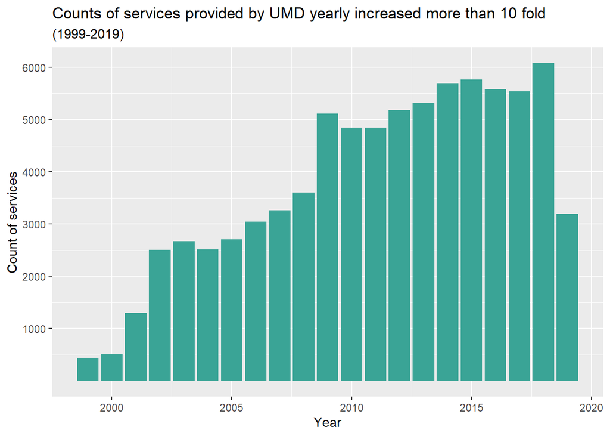

```r
# Create a subset of data with observations dated between 1999 and 2019
umd_9919 = umd %>%
  filter(between(year,1999,2019))

# Create a plot of counts of services by year
ggplot(data=umd_9919)+
  labs(   title = 'Counts of services provided by UMD yearly increased more than 10 fold',
       subtitle ='(1999-2019)',
              x = 'Year',
              y = 'Count of services')+
  geom_bar(aes(year),fill = "#3AA496")+
  scale_y_continuous(breaks = 1:6*1000)
```

### 3. How many new households joined UMD services yearly between 1999 and 2019?

Unlike the count of services, the number of new households joining UMD services each year did not increase as steadily, but fluctuated around 700 to 1000, and seemed to be related to the annual local unemployment rate (orange line), especially before 2015. It’s not very realistic to predict how many new households would join using unemployment rate, since unemployment rate is not released two or three months later. Conversely, the number of new households joining might give us an idea whether the economy and job market are doing well. If there is a upward trend, UMD might have to respond accordingly.

```r
# Obtain the date of first visit for each household
first = umd_9919 %>%
  select(id,date,year,month) %>%
  arrange(id,date) %>%
  group_by(id) %>%
  filter(row_number(date) == 1) %>%
  ungroup()

# Count the number of new households each year
first_by_year = first %>%  count(year)

# Reshape the table for presentation
cbind(first_by_year[1:11,],rbind(first_by_year[12:21,],c(NA,NA)))
```

```
##    year    n year    n
## 1  1999  169 2010 1007
## 2  2000   98 2011  869
## 3  2001  509 2012  875
## 4  2002  896 2013  838
## 5  2003  797 2014  984
## 6  2004  668 2015  865
## 7  2005  618 2016  914
## 8  2006  675 2017  840
## 9  2007  686 2018  937
## 10 2008  700 2019  389
## 11 2009 1009   NA   NA
```

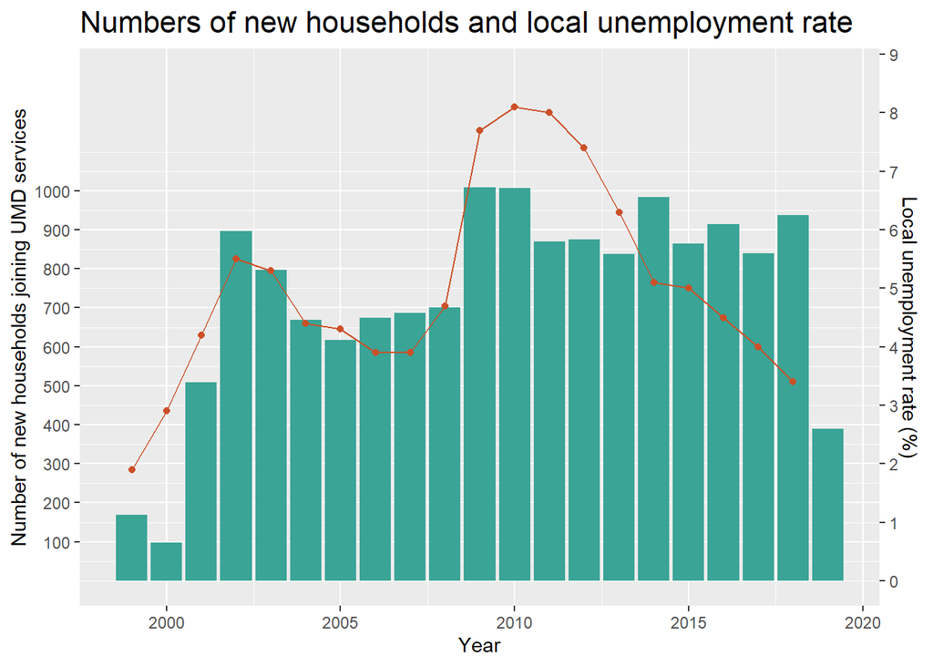

```r
# Obtain annual unemployment rates
unemp.ann = filter(unemp,period == 'Annual')

# Plot the number of new households agains year, and superimpose local umemployment rate
ggplot(data = first_by_year,aes(x=year,y=n))+
  labs(title = 'Numbers of new households and local unemployment rate',
           x = 'Year',
           y = 'Number of new households joining UMD services')+
  theme(plot.title = element_text(size=16))+
  geom_col(fill = "#3AA496")+
  geom_line(data = unemp.ann,aes(x = year,y = unemp.rate.n*150),color = '#cb5027')+
  geom_point(data = unemp.ann,aes(x = year,y = unemp.rate.n*150),color = '#cb5027')+
  scale_y_continuous(breaks = 1:10*100,limits = c(0,1300),
                     sec.axis = sec_axis(~ ./150,breaks=0:10,name = 'Local unemployment rate (%)'))
```

### 4. How many UMD services did households typically use?

Among 15343 unique households that used UMD services between 1999 and 2019, 6779 households used UMD services only once, which is about 44% of the households. On the other hand, more than 75% of households used UMD services no more than 5 times. The actual percentages would be lower because some households that joined later might not have their second (and above) visits to UMD yet. Still, it seems that most clients were able to get through their difficulties with the help of UMD, rather than depended on UMD on a regular, long-term basis.

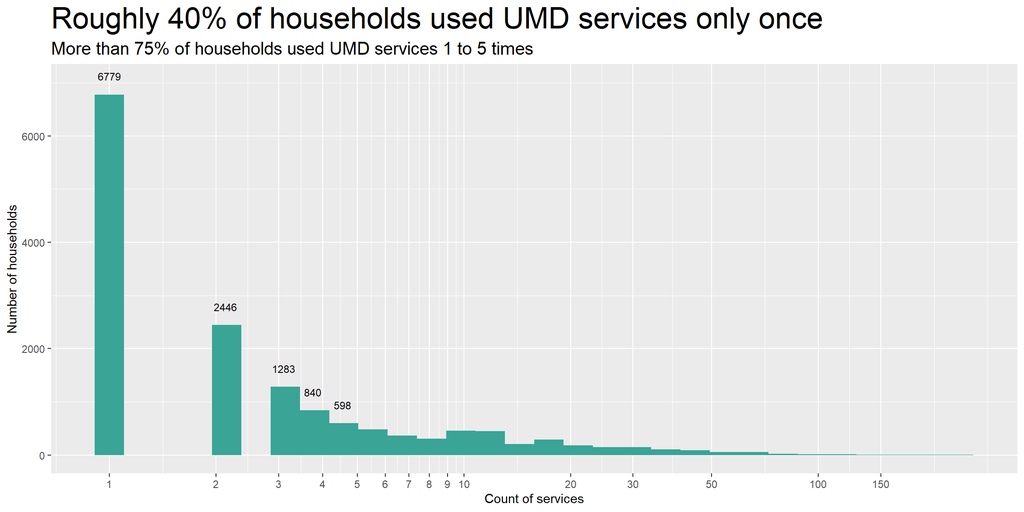

```r
# Compute length of intervals (days) between visits for each household
interval = umd_9919 %>%
  select(id,date) %>%
  arrange(id,date) %>%
  group_by(id) %>%
  mutate(interval = ifelse(row_number(date) != 1,date-lag(date),NA))

# Count how many times did each household use UMD services
times = interval %>%
  summarize(n.services=n()) %>%
  ungroup()

# Create labels for the following histogram
times_label = times %>%
  count(n.services) %>%
  filter(n.services <= 5)

# Plot the distribution of times household used UMD services. Log transform the x axis otherwise the right tail is too long.
times %>%
  ggplot(aes(x = n.services))+
  geom_histogram(fill='#3AA496')+
  scale_x_continuous(trans="log",breaks=c(1:10,20,30,50,100,150))+
  ylim(0,7000)+
  geom_text(data=times_label,
            mapping=aes(label = n,x = c(1,2.12,3.10,3.75,4.55),y = n),vjust = -1.8,size = 3)+
  labs(   title = 'Roughly 40% of households used UMD services only once',
       subtitle = 'More than 75% of households used UMD services 1 to 5 times',
              x = 'Count of services',
              y = 'Number of households')+
  theme(plot.title = element_text(size=25),
        plot.subtitle = element_text(size=15))
```

### 5. For households that used more than one UMD service, how long were the intervals between two services?

Among the 8564 households that used UMD services more than once, the intervals between two services ranged from 1 day to about 17.5 years, with the median being 42 days, which means that half of the intervals between services are 42 days or below. From the histogram below, it’s clear that the majority of intervals between two visits fell within 12 months (or one year). This reflect how often the households were in need, but the real intervals might be shorter given the clients could only shop once a month at the food pantry.

```r
# Summary statistics of intervals between two services (day)
summary(interval$interval[-which(is.na(interval$interval))])
```

```
##    Min. 1st Qu.  Median    Mean 3rd Qu.    Max.
##     1.0    28.0    42.0   138.4   100.0  6375.0
```

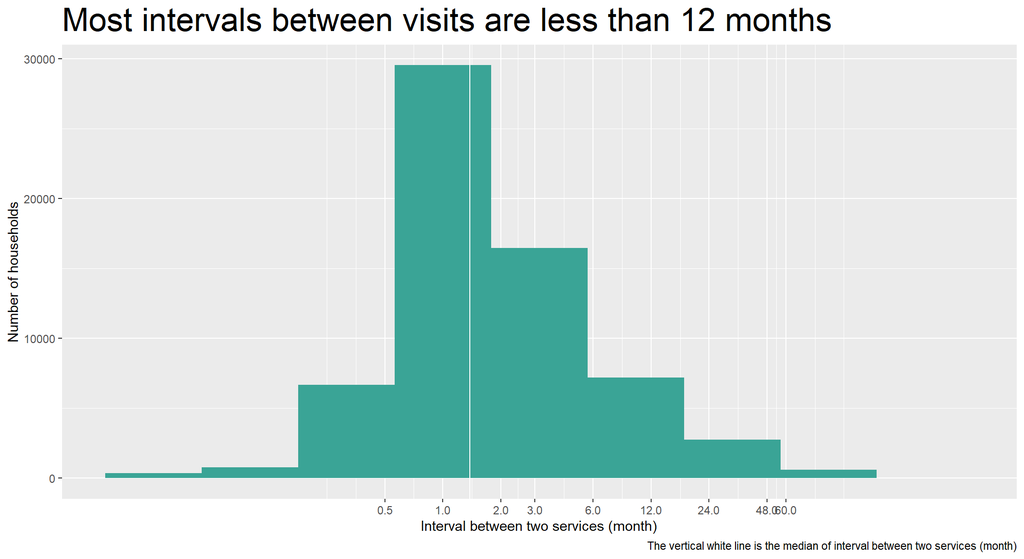

```r
# Obtain median of intervals in months
median_interval = median(interval$interval,na.rm=TRUE)/(365.25/12)

# Plot the distribution of intervals
interval %>%
  filter(!is.na(interval)) %>%
  mutate(interval.month = interval/(365.25/12)) %>%
  ggplot(aes(x = interval.month))+
    geom_histogram(binwidth = 0.5,fill = '#3AA496')+
    scale_x_continuous(trans = 'log10',breaks = c(0,0.5,1,2,3,6,12,24,48,60))+
    geom_vline(xintercept = median_interval,color = 'white')+
    labs(title = 'Most intervals between visits are less than 12 months',
             x = 'Interval between two services (month)',
             y = 'Number of households',
       caption = 'The vertical white line is the median of interval between two services (month)')+
    theme(plot.title = element_text(size = 25))
```

### 6. Among households receiving more than one service, how long did it take them to stand on their own feet, moved out of the community (including death), or in general, stopped using UMD services?

This question is harder to answer than it appears. First, we only know why households visited, not why they stopped coming, so we have no information to tackle the first two sub-questions. Second, the status of being independent is dynamic. To simplify the question, I only look at a subset of households satisfying the following criteria: i) received more than one service between 1999 and 2019, ii) had their first visits before 2017, and iii) had not visited after July, 2017, so they hadn’t visited UMD for the past two years. Then, the duration between their first and last visits are calculated.

```r
# Obtain the date of last visit for each household
last = umd_9919 %>%
  select(id,date,year,month) %>%
  arrange(id,desc(date)) %>%
  group_by(id) %>%
  filter(row_number(desc(date)) == 1) %>%
  ungroup()

# Calculate the duration between the first and the last visit for each household, in days and in months, and subset the data
first_last = first %>%
  left_join(last,by = "id") %>%
  mutate(duration = as.numeric(date.y-date.x)) %>%
  filter(duration > 0 & date.x<as.Date('2017-01-01') & date.y<as.Date('2017-07-19')) %>%
  mutate(duration.month = duration/(365.25/12))

# Summary statistics for the duration in days
summary.q6=summary(first_last$duration)
print(summary.q6)
```

```
##    Min. 1st Qu.  Median    Mean 3rd Qu.    Max.
##       1      93     383     813    1111    6669
```

The median duration of receiving UMD services is 383 days, or about one year, meaning that about 50% of households were able to stop using UMD in a year. The 75% percentile of the duration receiving UMD services is 1111 days, or about 3 years, which means that about 75% of households stopped using UMD services in about three years.

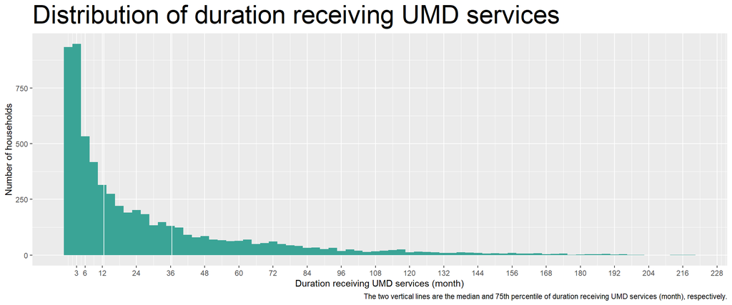

```r
# Plot the distribution of duration receiving UMD services
ggplot(data = first_last,aes(x = duration.month))+
  geom_histogram(binwidth = 3,fill = '#3AA496')+
  scale_x_continuous(breaks = c(3,6,12*1:20))+
  geom_vline(xintercept = summary.q6[3]/(365.25/12),color = 'white')+
  geom_vline(xintercept = summary.q6[5]/(365.25/12),color = 'white')+
  labs(title = 'Distribution of duration receiving UMD services',
           x = 'Duration receiving UMD services (month)',
           y = 'Number of households',
     caption = 'The two vertical lines are the median and 75th percentile of duration receiving UMD services (month), respectively.')+
  theme(plot.title = element_text(size = 30))
```

## Part B.Trends

### 1. Is there any particular season or month where UMD saw more households coming?

When the counts of visits each month are summed across years 1999 to 2018, surprisingly, there doesn’t seem to be a particular month or season with much higher or lower counts of services.

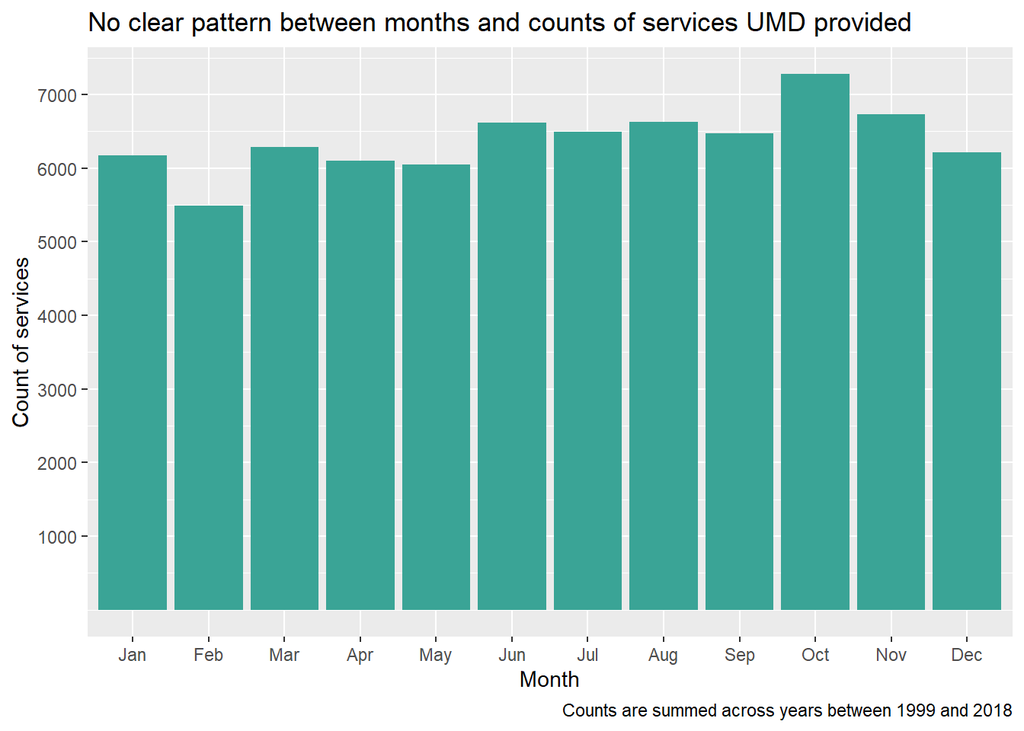

```r
# Count the number of services provided in 12 months across 1999 to 2018. 2019 data is excluded because we don't have a full year of data for 2019.
umd_9919 %>%
  filter(year < 2019) %>%
  ggplot(aes(x=factor(month)))+
  geom_bar(fill = '#3AA496')+
  scale_x_discrete(breaks = 1:12,
                   labels = c("Jan","Feb","Mar","Apr","May","Jun","Jul","Aug","Sep","Oct","Nov","Dec"))+
  labs(  title = 'No clear pattern between months and counts of services UMD provided',
       caption = 'Counts are summed across years between 1999 and 2018',
             x = 'Month',
             y = 'Count of services')+
  scale_y_continuous(breaks = 1:7*1000)
```

When counts of services are examined for each month from 1999 to 2019, still there is no clear pattern between month and the the count of services. One explanation is that we are looking at the total counts of services, thus there might be a pattern between month and the counts of certain types of services (eg. clothing or food).

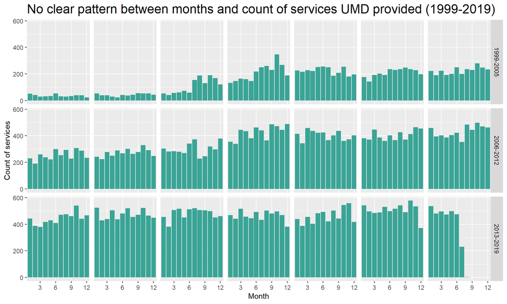

```r
# Create labels for the facet below
row_labels = c(row0 = "1999-2005",row1 = "2006-2012",row2 = "2013-2019")

# Plot the monthly count of services from 1999 to 2019
umd_9919 %>%
  mutate(row = paste('row',(year-1999)%/%7,sep = ''),col = (year-1999)%%7) %>%  #create two variables to help faceting
  ggplot(aes(x = factor(month)))+
    geom_bar(fill = '#3AA496')+
    facet_grid(row ~ col,labeller = labeller(row = row_labels))+
    theme(strip.text.x = element_blank())+
    scale_x_discrete(breaks = 3*1:4)+
    labs(title = 'No clear pattern between months and count of services UMD provided (1999-2019)',
             x = 'Month',
             y = 'Count of services')+
    theme(plot.title = (element_text(size = 18)))
```

### 2. Is there any particular season or month where UMD saw more new households coming?

Similarly, there doesn’t seem to be a clear pattern between season/month and the number of new households joining UMD services.

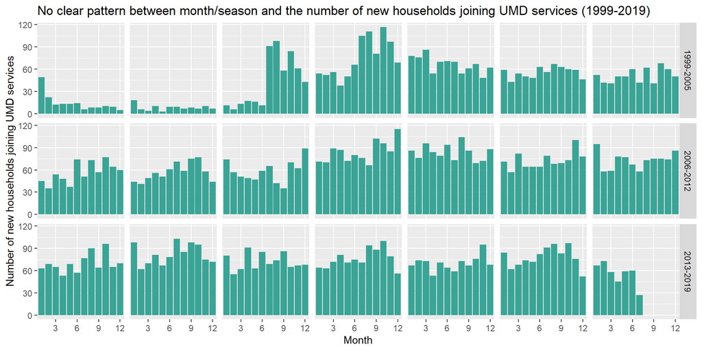

```r
# Plot the distribution of the monthly number of new households joining UMD services in 1999-2019
first %>%
  mutate(row = paste('row',(year-1999)%/%7,sep = ''),col = (year-1999)%%7) %>%  #create two variables to help faceting
  ggplot(aes(x = factor(month)))+
  geom_bar(fill = '#3AA496')+
  facet_grid(row ~ col,labeller = labeller(row = row_labels))+
  theme(strip.text.x = element_blank())+
  scale_x_discrete(breaks = 3*1:4)+
  labs(title = 'No clear pattern between month/season and the number of new households joining UMD services (1999-2019)',
           x = 'Month',
           y = 'Number of new households joining UMD services')+
  theme(plot.title = (element_text(size = 13)))
```

As a continuation of Part A question 3, the monthly unemployment rates from 1999 to 2019 are also plotted. Just by comparing the two plots, it’s debatable whether there is a relationship between unemployment rate and the number of new households using UMD services.

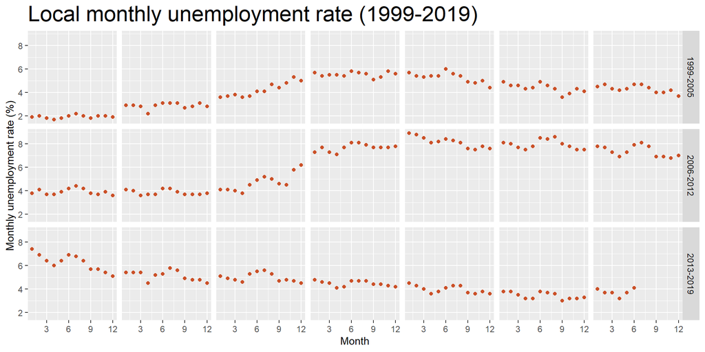

```r
# The months in the unemployment data set are saved as characters (eg. Jan) rather than numbers. Create a dataset that link character months to numeric months, which could be merged with the enemployment dataset. This helps with graphing the monthly unemployment rate and comparing to the plot above.
month.c_to_n = tibble(month.n=1:12,month.c=c("Jan","Feb","Mar","Apr","May","Jun","Jul","Aug","Sep","Oct","Nov","Dec"))

# Plot monthly local unemployment rate from 1999 to 2019
unemp %>%
  filter(period != 'Annual') %>%
  left_join(month.c_to_n,by = c("period" = "month.c")) %>%
  mutate(row = paste('row',(year-1999)%/%7,sep = ''),col = (year-1999)%%7) %>%               #create two variables to help faceting
  ggplot(aes(x = month.n,y = unemp.rate.n))+
  geom_point(color = '#cb5027')+
  facet_grid(row ~ col,labeller = labeller(row = row_labels))+
  theme(strip.text.x = element_blank())+
  scale_x_continuous(breaks = 3*1:4)+
  scale_y_continuous(breaks = c(2,4,6,8))+
  labs(title = 'Local monthly unemployment rate (1999-2019)',
           x = 'Month',
           y = 'Monthly unemployment rate (%)')+
  theme(plot.title=element_text(size = 22))
```

# Conclusion

During the past 21 years, UMD served a large and increasing community of people in need, and 3 quarters of which were able to stop using UMD services in about three years. Month and season did not seem to affect the (total) count of services they provided or the number of new clients, although the result presented here does not rule out the possibility that the counts of specific types of services might differ from month to month or season to season. This is a more visual and less statistically rigorous exploratory analysis, but it might be interesting to include local unemployment rate as an explanatory variable for the number of new households joining UMD services in the future.